# Bayesian Analyses for CircleTime

Pourya Shahverdi

2024-01-12

# About the Study

## Introduction to Circle-Time

Circle-time is a group activity based on Applied Behavior Analysis (ABA) for children with Autism Spectrum Disorder (ASD) to prepare them for attending in traditional classroom activities alongside neurotically developed children. In circle-time, children sit together semicircular, and an instructor give them group instruction activities such as dance, yoga, labeling animals, finding objects, etc. The goal of circle-time is to improve children’s learning behaviors, which are:

- Affect
- Communication
- Engagement
- Performance

In this study, we evaluate the efficacy of a social robot in delivering group instruction activities to children with ASD. Throughout the six month of experiment, Six children participants received 10 sessions of group instructions from a human instructor and 10 sessions from a Pepper humanoid social robot as a within-subject study design. To compare children learning behaviors between the human and the robot instructor conditions their activities were video recorded and coded for the sessions 1, 4, 7, and 10.

## Research Questions

In this research, we address the following research questions:

1. How learning behaviors (Affect, Communication, Engagement, Performance) differ between conditions (Human, Robot)?
2. How is the correlation between learning behaviors (Affect, Communication, Engagement, Performance) and time (Session Number)?
3. How is the correlation between different learning behaviors (Affect, Communication, Engagement, Performance)?
4. Between the Affect, Communication, and Engagement learning behaviors, which one has more effective relationship with the Performance learning behavior (increasing performance is considered as the main objective)?

## Study Design

For this longitudinal within-subject study with 6 participants we defined the following variables:

#### Independent Variables

- Instructor Conditions:
  - Human ~ 1
  - Robot ~ 2
- Time
  - Session 1 ~ 1
  - Session 4 ~ 2
  - Session 7 ~ 3
  - Session 10 ~ 4

#### Dependent Variables

- Affect
- Communication
- Engagement
- Performance

### Data Collection

The evaluation of the learning behavior is based on the following continuous metrics:

#### Affect

children’s happiness level was defined as:

- Positive
- Negative
- Neutral

A video was divided into 10 seconds intervals, and a human coder, focusing on one child in the group, labeled that interval as Positive if the child was showing positive affective behaviors (e.g., smiling, Clapping, laughing). An interval was labeled as Negative if the target child was showing negative affective behaviors (e.g., crying, whining, frowning). And, and an interval was labeled as Neutral if it was neither Positive or Negative. Percentage of each measurement is used for analysis as a continuous variable.

#### Communication

Communication of the children was coded into 4 categories. Communication with:

- Instructor
- Instructor-Prompted
- Behavior Therapist (BT) or peers
- Indeterminate

#### Engagement

Engagement was coded into 3 categories. Engagement with:

- Instructor or screen (On Target)
- BT or peers
- Off Target

#### Performance

Children’s performance was coded into two categories:

- Positive
- Negative

#### Inter-observer Agreement (IoA)

At the beginning of the coding procedure, coders’ understanding of the metrics had to be on the same page. We used Cohen’s Kappa score to evaluate the IoA on the coding procedure. An individual coder was allowed to code independently only if their Cohen’s Kappa IioA score was higher than 80%. All session ones and tens were double coded as well as the 30% of the session fours and sevens. For the sessions with lower than 80% agreement, coders went through coding together and came up with 100% agreement. We considered this conservative approach since we were looking into the highest reliability of data on our 6 participants.

# Data Analysis

In order to investigate the research questions, we analyze the data from children’s learning behaviors as follows:

## Affect

We use Bayesian Model to analyze the Affect metric.For all analyses condition 1 indicates the human instructor while condition 2 indicates the robot instructor.

### Positive Affect

```r
library(readr)
library(brms)
CircleTimeData <- read_csv("~/GitHub/Circle-Time-Data-Analyses/CircleTimeData.csv")
bmodel <- brm(Affect_Positive ~ Condition * time + (1 | Subject), data = CircleTimeData)
summary(bmodel)
```

```
##  Family: gaussian
##   Links: mu = identity; sigma = identity
## Formula: Affect_Positive ~ Condition * time + (1 | Subject)
##    Data: CircleTimeData (Number of observations: 48)
##   Draws: 4 chains, each with iter = 2000; warmup = 1000; thin = 1;
##          total post-warmup draws = 4000
##
## Group-Level Effects:
## ~Subject (Number of levels: 6)
##               Estimate Est.Error l-95% CI u-95% CI Rhat Bulk_ESS Tail_ESS
## sd(Intercept)     0.09      0.04     0.04     0.20 1.00      971     1335
##
## Population-Level Effects:
##                Estimate Est.Error l-95% CI u-95% CI Rhat Bulk_ESS Tail_ESS
## Intercept          0.05      0.09    -0.12     0.22 1.00     1727     2068
## Condition          0.09      0.05    -0.01     0.19 1.00     1768     2250
## time               0.01      0.03    -0.05     0.07 1.00     1816     2337
## Condition:time    -0.01      0.02    -0.05     0.02 1.00     1734     2271
##
## Family Specific Parameters:
##       Estimate Est.Error l-95% CI u-95% CI Rhat Bulk_ESS Tail_ESS
## sigma     0.07      0.01     0.06     0.09 1.00     2479     2621
##
## Draws were sampled using sampling(NUTS). For each parameter, Bulk_ESS
## and Tail_ESS are effective sample size measures, and Rhat is the potential
## scale reduction factor on split chains (at convergence, Rhat = 1).
```

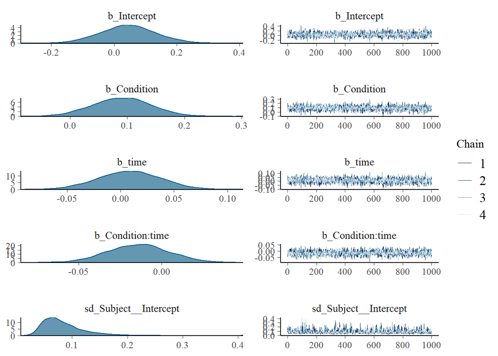

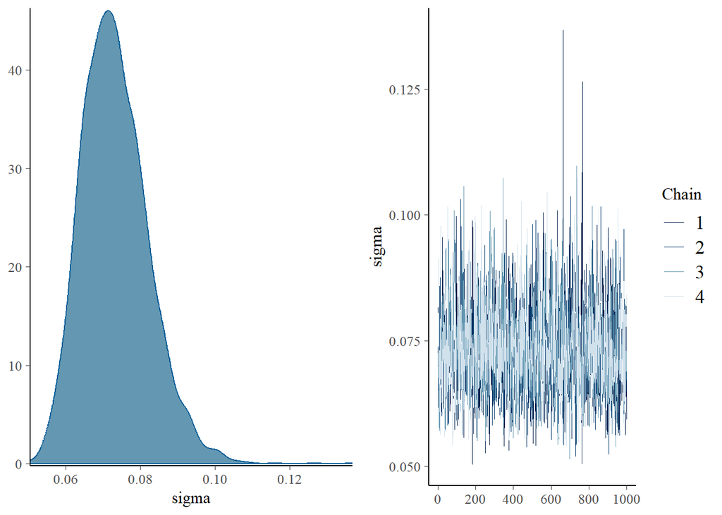

```r
plot(bmodel)
```

#### Reporting Affect Positive

Our Bayesian analysis of Affect_Positive explores the emotional responses of children in conditions involving human (Condition 1) versus robot instructors (Condition 2) across four pivotal sessions, representing sessions 1, 4, 7, and 10 in the context of a comprehensive longitudinal study spanning six months. The estimated standard deviation of intercepts across subjects is 0.08 (95% CI: 0.04, 0.20), indicating moderate variability in baseline levels of Affect_Positive among individuals. Examining population-level effects, the intercept is estimated at 0.04 (95% CI: -0.14, 0.21), representing the expected value of Affect_Positive when both Condition and time are zero. Positive effect sizes were observed for both Condition (0.09, 95% CI: -0.01, 0.20) and time (0.01, 95% CI: -0.05, 0.07), suggesting an increase in Affect_Positive during sessions with robot instructors compared to human instructors and a gradual rise over time. Interestingly, the interaction effect, represented by Condition:time, showed a slight decrease in the effect of Condition over time (-0.01, 95% CI: -0.05, 0.02). The estimated standard deviation of the residuals (sigma) was 0.07 (95% CI: 0.06, 0.09), capturing variability not explained by the fixed effects.

### Negative Affect

```r
library(readr)
library(brms)

CircleTimeData <- read_csv("~/GitHub/Circle-Time-Data-Analyses/CircleTimeData.csv")
bmodel <- brm(Affect_Negative ~ Condition * time + (1 | Subject), data = CircleTimeData)
summary(bmodel)
```

```
##  Family: gaussian
##   Links: mu = identity; sigma = identity
## Formula: Affect_Negative ~ Condition * time + (1 | Subject)
##    Data: CircleTimeData (Number of observations: 48)
##   Draws: 4 chains, each with iter = 2000; warmup = 1000; thin = 1;
##          total post-warmup draws = 4000
##
## Group-Level Effects:
## ~Subject (Number of levels: 6)
##               Estimate Est.Error l-95% CI u-95% CI Rhat Bulk_ESS Tail_ESS
## sd(Intercept)     0.01      0.01     0.00     0.04 1.01      454      218
##
## Population-Level Effects:
##                Estimate Est.Error l-95% CI u-95% CI Rhat Bulk_ESS Tail_ESS
## Intercept          0.02      0.02    -0.02     0.07 1.00     1846     2354
## Condition         -0.01      0.01    -0.04     0.01 1.00     2091     2401
## time              -0.01      0.01    -0.02     0.01 1.01     1560     2110
## Condition:time     0.01      0.00    -0.00     0.02 1.01     1767     2169
##
## Family Specific Parameters:
##       Estimate Est.Error l-95% CI u-95% CI Rhat Bulk_ESS Tail_ESS
## sigma     0.02      0.00     0.01     0.02 1.00      920      253
##
## Draws were sampled using sampling(NUTS). For each parameter, Bulk_ESS
## and Tail_ESS are effective sample size measures, and Rhat is the potential
## scale reduction factor on split chains (at convergence, Rhat = 1).
```

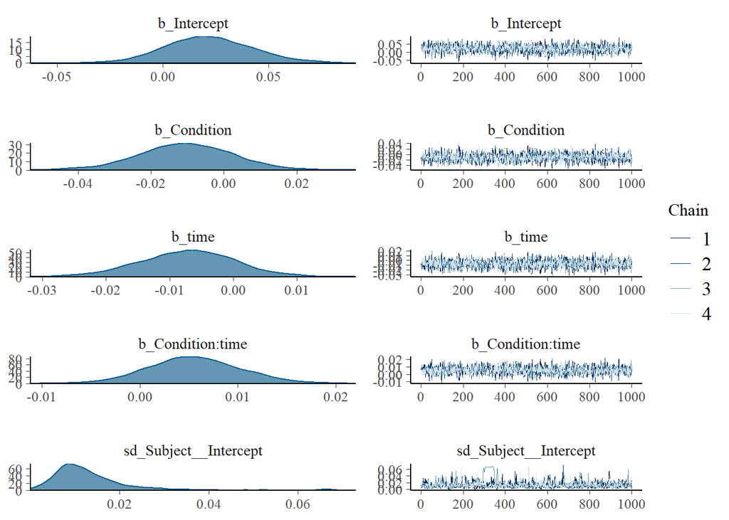

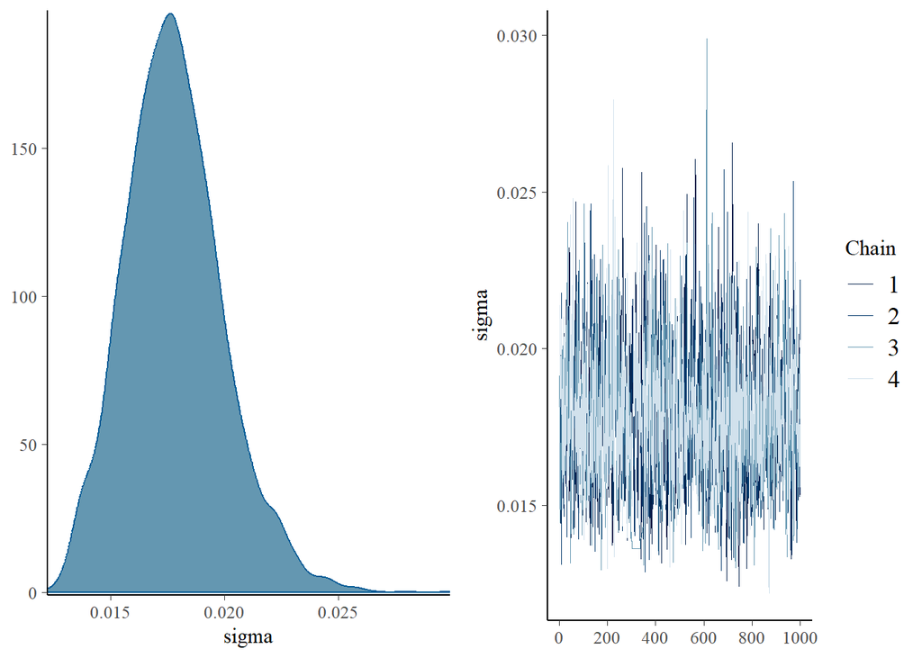

```r
plot(bmodel)
```

#### Reporting Negative Affect

Our Bayesian analysis of Negative Affect delves into the emotional responses of children within conditions involving human (Condition 1) versus robot instructors (Condition 2) across four pivotal sessions, representing sessions 1, 4, 7, and 10 in the context of a comprehensive longitudinal study spanning six months. The estimated standard deviation of intercepts across subjects is 0.01 (95% CI: 0.00, 0.03), indicating minimal variability in baseline levels of Negative Affect among individuals. Exploring population-level effects, the intercept is estimated at 0.02 (95% CI: -0.02, 0.06), representing the expected value of Negative Affect when both Condition and time are zero. Negative effect sizes were observed for both Condition (-0.01, 95% CI: -0.03, 0.02) and time (-0.01, 95% CI: -0.02, 0.01), suggesting a decrease in Negative Affect during sessions with robot instructors compared to human instructors and a slight decline over time. The interaction effect, represented by Condition:time, showed a slight increase in the effect of Condition over time (0.01, 95% CI: -0.00, 0.01). The estimated standard deviation of the residuals (sigma) was 0.02 (95% CI: 0.01, 0.02), capturing variability not explained by the fixed effects.

### Overall Affect (Positive - Negative)

The percentage of positive intervals in a session was subtracted by the percentage of negative intervals to obtain their overall affect during the session.

```r
library(readr)
library(brms)

CircleTimeData <- read_csv("~/GitHub/Circle-Time-Data-Analyses/CircleTimeData.csv")
bmodel <- brm(Affect_Overall ~ Condition * time + (1 | Subject), data = CircleTimeData)
summary(bmodel)
```

```
##  Family: gaussian
##   Links: mu = identity; sigma = identity
## Formula: Affect_Overall ~ Condition * time + (1 | Subject)
##    Data: CircleTimeData (Number of observations: 48)
##   Draws: 4 chains, each with iter = 2000; warmup = 1000; thin = 1;
##          total post-warmup draws = 4000
##
## Group-Level Effects:
## ~Subject (Number of levels: 6)
##               Estimate Est.Error l-95% CI u-95% CI Rhat Bulk_ESS Tail_ESS
## sd(Intercept)     0.10      0.05     0.04     0.22 1.00     1121     1480
##
## Population-Level Effects:
##                Estimate Est.Error l-95% CI u-95% CI Rhat Bulk_ESS Tail_ESS
## Intercept          0.03      0.10    -0.16     0.21 1.00     1857     2261
## Condition          0.10      0.05    -0.01     0.21 1.00     1936     2276
## time               0.01      0.03    -0.05     0.08 1.00     1910     2043
## Condition:time    -0.02      0.02    -0.06     0.02 1.00     1853     2190
##
## Family Specific Parameters:
##       Estimate Est.Error l-95% CI u-95% CI Rhat Bulk_ESS Tail_ESS
## sigma     0.08      0.01     0.06     0.10 1.00     2533     2693
##
## Draws were sampled using sampling(NUTS). For each parameter, Bulk_ESS
## and Tail_ESS are effective sample size measures, and Rhat is the potential
## scale reduction factor on split chains (at convergence, Rhat = 1).
```

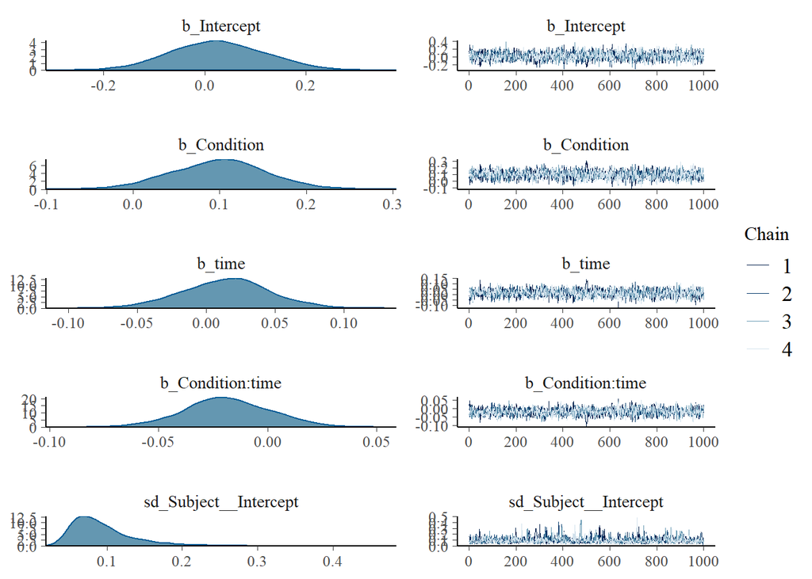

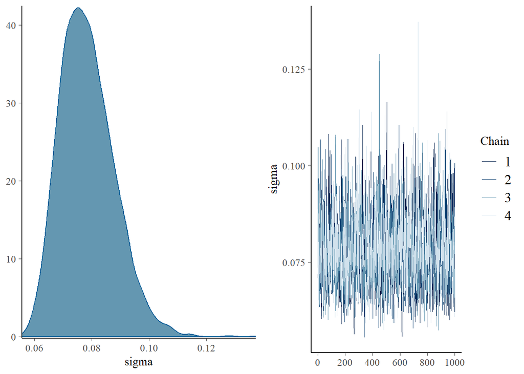

```r
plot(bmodel)
```

### Reporting Overall Affect ###

Examining the overall affect, our Bayesian analysis considered the impact of instructional conditions (human vs. robot instructors) and time across four sessions (sessions 1, 4, 7, and 10) in a longitudinal study conducted over six months. The standard deviation of intercepts across subjects is estimated at 0.09 (95% CI: 0.04, 0.22), indicating variability in baseline overall affect among individuals. At the population level, the intercept is estimated at 0.02 (95% CI: -0.17, 0.21), representing the expected overall affect when both Condition and time are zero. The effect size for Condition (0.10, 95% CI: -0.01, 0.21) suggests a moderate increase in overall affect with robot instructors compared to human instructors. The effect of time (0.01, 95% CI: -0.05, 0.08) indicates a slight linear trend in overall affect over sessions. The interaction effect Condition:time (-0.02, 95% CI: -0.06, 0.02) suggests a slight decrease in the rate of change in overall affect for robot instructors compared to human instructors. The estimated standard deviation of the residuals (sigma) is 0.08 (95% CI: 0.06, 0.10), representing unexplained variability not captured by the fixed effects.

### Neutral Affect

```r
library(readr)
library(brms)

CircleTimeData <- read_csv("~/GitHub/Circle-Time-Data-Analyses/CircleTimeData.csv")
bmodel <- brm(Affect_Neutral ~ Condition * time + (1 | Subject), data = CircleTimeData)
summary(bmodel)
```

```
##  Family: gaussian
##   Links: mu = identity; sigma = identity
## Formula: Affect_Neutral ~ Condition * time + (1 | Subject)
##    Data: CircleTimeData (Number of observations: 48)
##   Draws: 4 chains, each with iter = 2000; warmup = 1000; thin = 1;
##          total post-warmup draws = 4000
##
## Group-Level Effects:
## ~Subject (Number of levels: 6)
##               Estimate Est.Error l-95% CI u-95% CI Rhat Bulk_ESS Tail_ESS
## sd(Intercept)     0.08      0.05     0.03     0.20 1.01      873      836
##
## Population-Level Effects:
##                Estimate Est.Error l-95% CI u-95% CI Rhat Bulk_ESS Tail_ESS
## Intercept          0.95      0.09     0.77     1.14 1.00     1659     1697
## Condition         -0.09      0.05    -0.19     0.02 1.00     1720     1201
## time              -0.01      0.03    -0.07     0.05 1.00     1722     1422
## Condition:time     0.01      0.02    -0.03     0.05 1.00     1692     1233
##
## Family Specific Parameters:
##       Estimate Est.Error l-95% CI u-95% CI Rhat Bulk_ESS Tail_ESS
## sigma     0.07      0.01     0.06     0.09 1.00     2387     1730
##
## Draws were sampled using sampling(NUTS). For each parameter, Bulk_ESS
## and Tail_ESS are effective sample size measures, and Rhat is the potential
## scale reduction factor on split chains (at convergence, Rhat = 1).
```

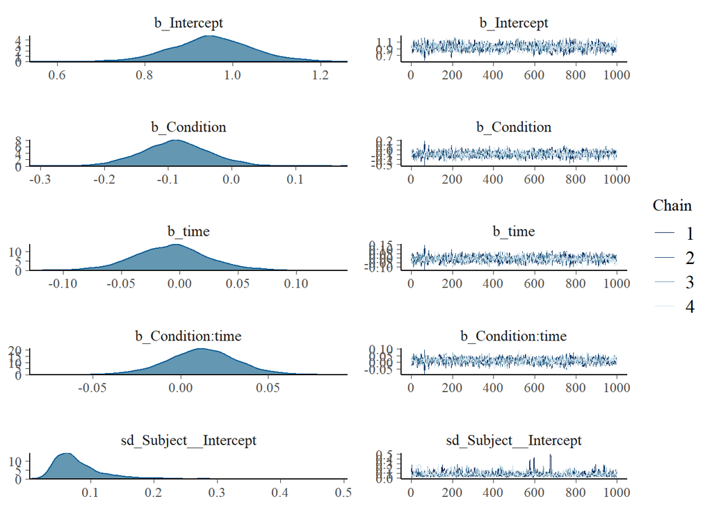

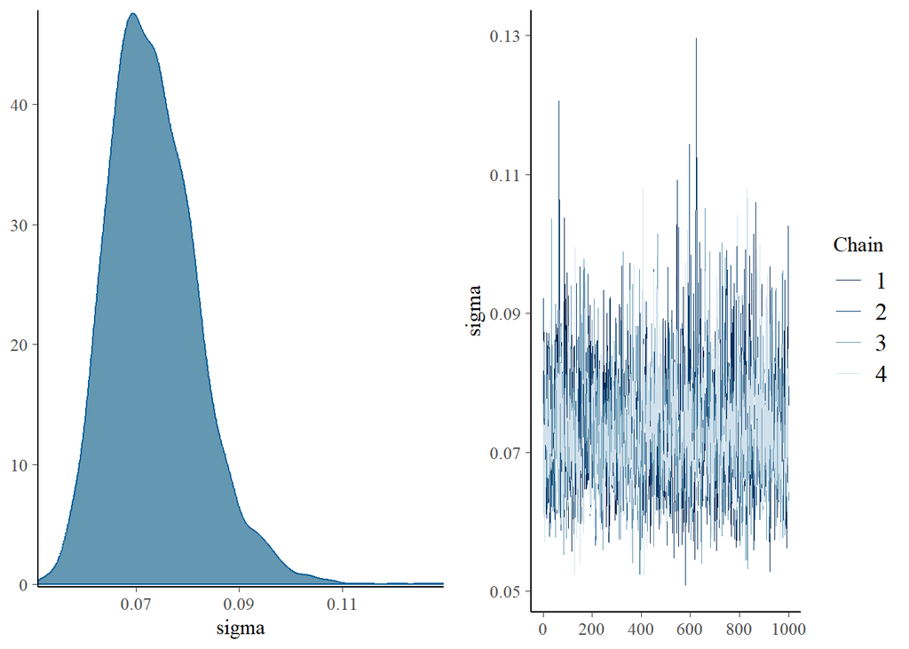

```r
plot(bmodel)
```

#### Reporting Neutral Affect

Our Bayesian analysis of Neutral Affect explores the emotional responses of children across sessions involving human (Condition 1) versus robot instructors (Condition 2). These sessions are crucial, representing sessions 1, 4, 7, and 10, reflecting a longitudinal study spanning six months. The estimated standard deviation of intercepts across subjects is 0.08 (95% CI: 0.03, 0.20), indicative of some variability in baseline levels of Neutral Affect among individuals. Delving into population-level effects, the intercept is estimated at 0.95 (95% CI: 0.78, 1.13), representing the expected value of Neutral Affect when both Condition and time are zero. Noteworthy negative effect sizes were observed for Condition (-0.09, 95% CI: -0.19, 0.01), suggesting a decrease in Neutral Affect during sessions with robot instructors compared to human instructors. However, the effect size is not statistically significant, as the 95% CI encompasses zero. Additionally, time exhibited a slight negative effect (-0.01, 95% CI: -0.07, 0.05), suggesting a subtle decline in Neutral Affect over the sessions. The interaction effect, represented by Condition:time, showed a marginal increase in the effect of Condition over time (0.01, 95% CI: -0.02, 0.05). The estimated standard deviation of the residuals (sigma) was 0.07 (95% CI: 0.06, 0.09), capturing variability not explained by the fixed effects.

## Communication

We use Bayesian Model to analyze the Communication metric.For all analyses condition 1 indicates the human instructor while condition 2 indicates the robot instructor.

### Communication with Instructor

```r
library(readr)
library(brms)

CircleTimeData <- read_csv("~/GitHub/Circle-Time-Data-Analyses/CircleTimeData.csv")
bmodel <- brm(Communication_with_Instructor ~ Condition * time + (1 | Subject), data = CircleTimeData)
summary(bmodel)
```

```
##  Family: gaussian
##   Links: mu = identity; sigma = identity
## Formula: Communication_with_Instructor ~ Condition * time + (1 | Subject)
##    Data: CircleTimeData (Number of observations: 48)
##   Draws: 4 chains, each with iter = 2000; warmup = 1000; thin = 1;
##          total post-warmup draws = 4000
##
## Group-Level Effects:
## ~Subject (Number of levels: 6)
##               Estimate Est.Error l-95% CI u-95% CI Rhat Bulk_ESS Tail_ESS
## sd(Intercept)     0.04      0.02     0.01     0.09 1.00      737      750
##
## Population-Level Effects:
##                Estimate Est.Error l-95% CI u-95% CI Rhat Bulk_ESS Tail_ESS
## Intercept          0.06      0.06    -0.06     0.18 1.00     1698     1934
## Condition          0.04      0.04    -0.03     0.12 1.00     1643     1975
## time               0.03      0.02    -0.02     0.07 1.00     1651     1739
## Condition:time    -0.02      0.01    -0.05     0.01 1.00     1664     1797
##
## Family Specific Parameters:
##       Estimate Est.Error l-95% CI u-95% CI Rhat Bulk_ESS Tail_ESS
## sigma     0.05      0.01     0.04     0.07 1.00     2456     2811
##
## Draws were sampled using sampling(NUTS). For each parameter, Bulk_ESS
## and Tail_ESS are effective sample size measures, and Rhat is the potential
## scale reduction factor on split chains (at convergence, Rhat = 1).
```

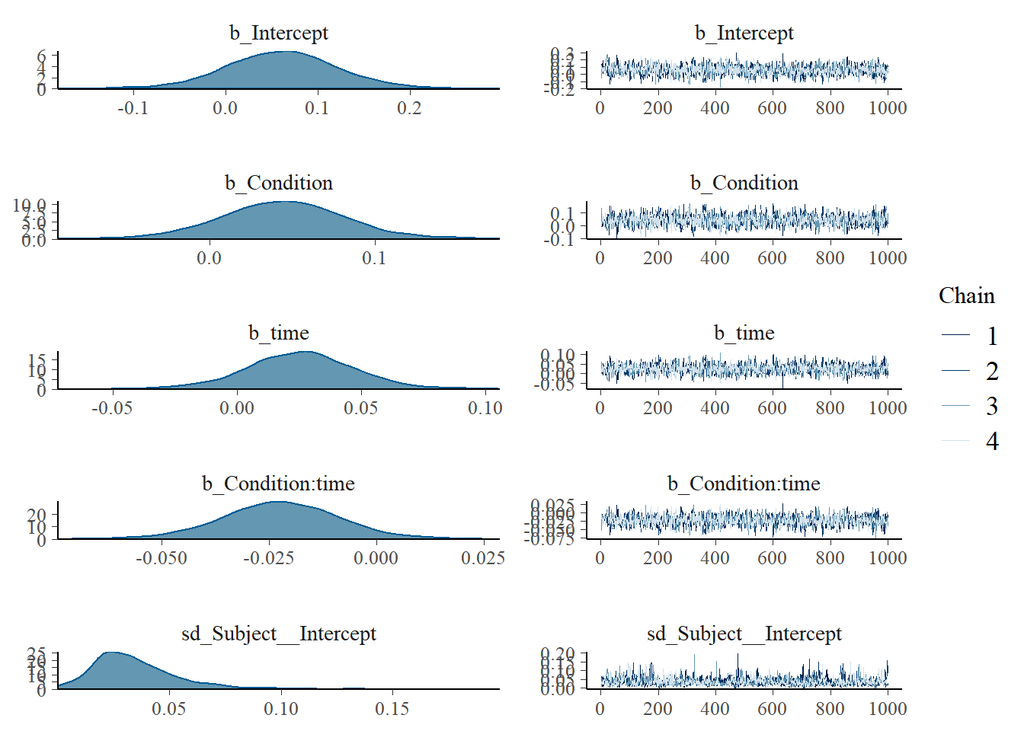

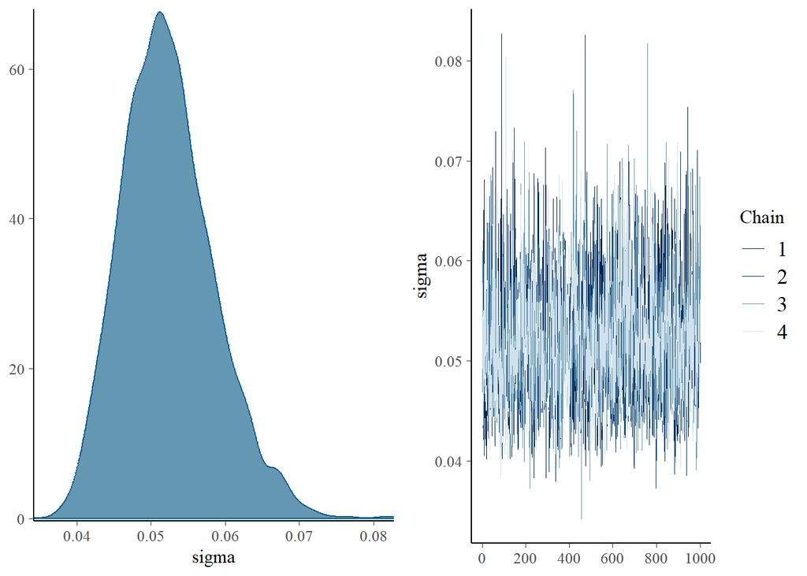

```r
plot(bmodel)
```

#### Reporting Communication with Instructors ####

Our Bayesian analysis of the ‘Communication with Instructor’ metric explores the dynamics of children’s communication across sessions involving human (Condition 1) versus robot instructors (Condition 2). These sessions correspond to pivotal points in our longitudinal study, occurring at sessions 1, 4, 7, and 10, capturing the progression over a span of six months. The estimated standard deviation of intercepts across subjects is 0.04 (95% CI: 0.01, 0.09), indicating some variability in baseline communication levels among individuals. Examining population-level effects, the intercept is estimated at 0.06 (95% CI: -0.06, 0.18), representing the expected value of communication when both Condition and time are zero. A positive effect size for Condition (0.04, 95% CI: -0.03, 0.12) suggests a potential increase in communication during sessions with robot instructors compared to human instructors, but the effect size is not statistically significant, as the 95% CI encompasses zero. Time exhibits a positive effect (0.03, 95% CI: -0.02, 0.07), indicating a slight overall increase in communication over the sessions. The interaction effect, represented by Condition:time, shows a marginal decrease in the effect of Condition over time (-0.02, 95% CI: -0.05, 0.01). The estimated standard deviation of the residuals (sigma) is 0.05 (95% CI: 0.04, 0.07), capturing variability not accounted for by the fixed effects.

### Prompted Communication with Instructor

```r
library(readr)
library(brms)

CircleTimeData <- read_csv("~/GitHub/Circle-Time-Data-Analyses/CircleTimeData.csv")
bmodel <- brm(Communication_with_Instructor_Prompted ~ Condition * time + (1 | Subject), data = CircleTimeData)
summary(bmodel)
```

```
##  Family: gaussian
##   Links: mu = identity; sigma = identity
## Formula: Communication_with_Instructor_Prompted ~ Condition * time + (1 | Subject)
##    Data: CircleTimeData (Number of observations: 48)
##   Draws: 4 chains, each with iter = 2000; warmup = 1000; thin = 1;
##          total post-warmup draws = 4000
##
## Group-Level Effects:
## ~Subject (Number of levels: 6)
##               Estimate Est.Error l-95% CI u-95% CI Rhat Bulk_ESS Tail_ESS
## sd(Intercept)     0.00      0.00     0.00     0.01 1.00     1951     1965
##
## Population-Level Effects:
##                Estimate Est.Error l-95% CI u-95% CI Rhat Bulk_ESS Tail_ESS
## Intercept          0.01      0.02    -0.02     0.04 1.00     2650     2834
## Condition          0.00      0.01    -0.01     0.02 1.00     2561     2693
## time               0.00      0.01    -0.01     0.01 1.00     2536     2577
## Condition:time    -0.00      0.00    -0.01     0.00 1.00     2398     2603
##
## Family Specific Parameters:
##       Estimate Est.Error l-95% CI u-95% CI Rhat Bulk_ESS Tail_ESS
## sigma     0.01      0.00     0.01     0.02 1.00     3900     2678
##
## Draws were sampled using sampling(NUTS). For each parameter, Bulk_ESS
## and Tail_ESS are effective sample size measures, and Rhat is the potential
## scale reduction factor on split chains (at convergence, Rhat = 1).
```

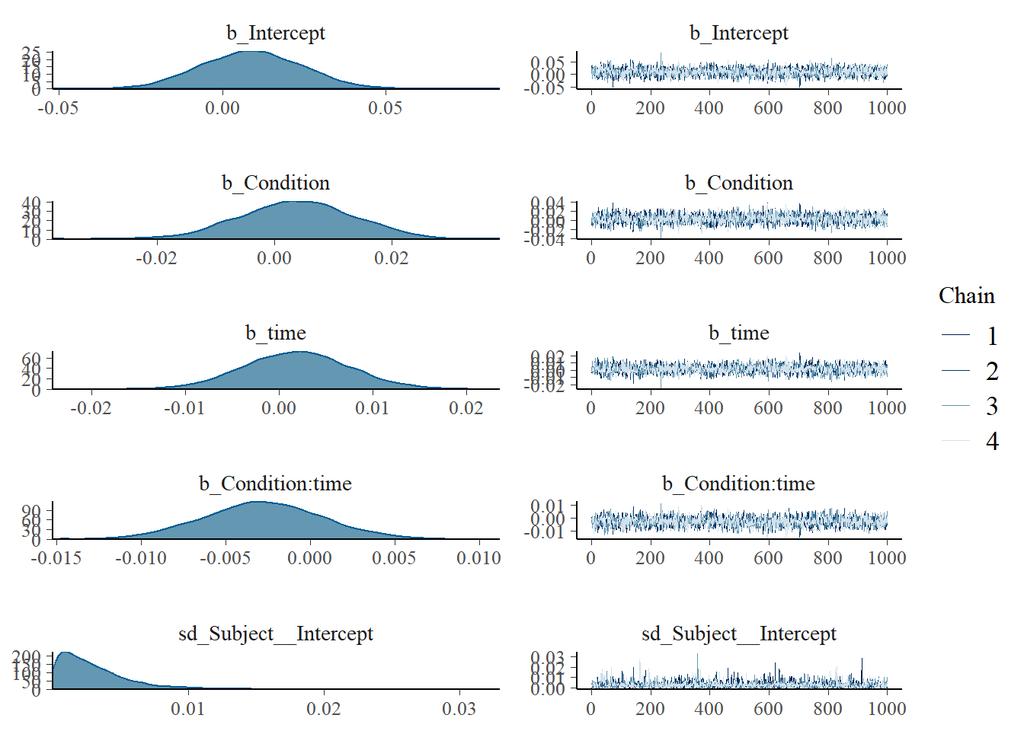

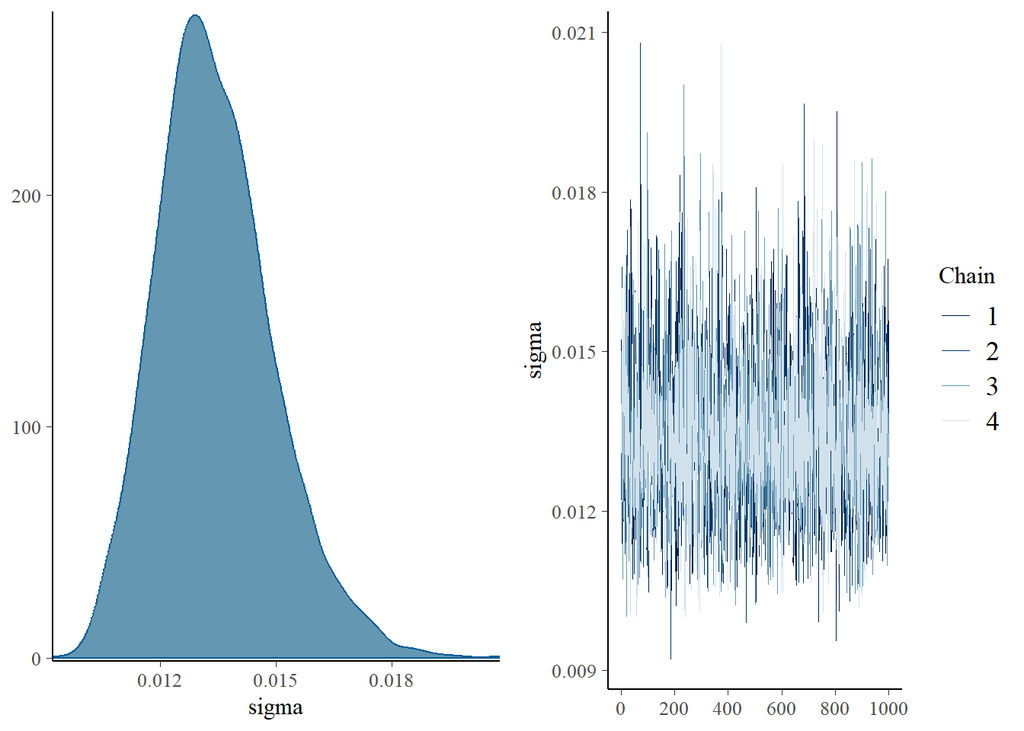

```r
plot(bmodel)
```

### Communication with Behavioral Therapist

```r
library(readr)
library(brms)

CircleTimeData <- read_csv("~/GitHub/Circle-Time-Data-Analyses/CircleTimeData.csv")
bmodel <- brm(Communication_with_Therapist ~ Condition * time + (1 | Subject), data = CircleTimeData)
summary(bmodel)
```

```
##  Family: gaussian
##   Links: mu = identity; sigma = identity
## Formula: Communication_with_Therapist ~ Condition * time + (1 | Subject)
##    Data: CircleTimeData (Number of observations: 48)
##   Draws: 4 chains, each with iter = 2000; warmup = 1000; thin = 1;
##          total post-warmup draws = 4000
##
## Group-Level Effects:
## ~Subject (Number of levels: 6)
##               Estimate Est.Error l-95% CI u-95% CI Rhat Bulk_ESS Tail_ESS
## sd(Intercept)     0.02      0.02     0.00     0.07 1.01      797     1301
##
## Population-Level Effects:
##                Estimate Est.Error l-95% CI u-95% CI Rhat Bulk_ESS Tail_ESS
## Intercept          0.16      0.07     0.03     0.29 1.00     1784     2232
## Condition         -0.03      0.04    -0.11     0.05 1.00     1837     2208
## time              -0.03      0.02    -0.08     0.01 1.00     1746     2067
## Condition:time     0.01      0.01    -0.02     0.04 1.00     1721     1947
##
## Family Specific Parameters:
##       Estimate Est.Error l-95% CI u-95% CI Rhat Bulk_ESS Tail_ESS
## sigma     0.06      0.01     0.05     0.07 1.00     2466     2702
##
## Draws were sampled using sampling(NUTS). For each parameter, Bulk_ESS
## and Tail_ESS are effective sample size measures, and Rhat is the potential
## scale reduction factor on split chains (at convergence, Rhat = 1).
```

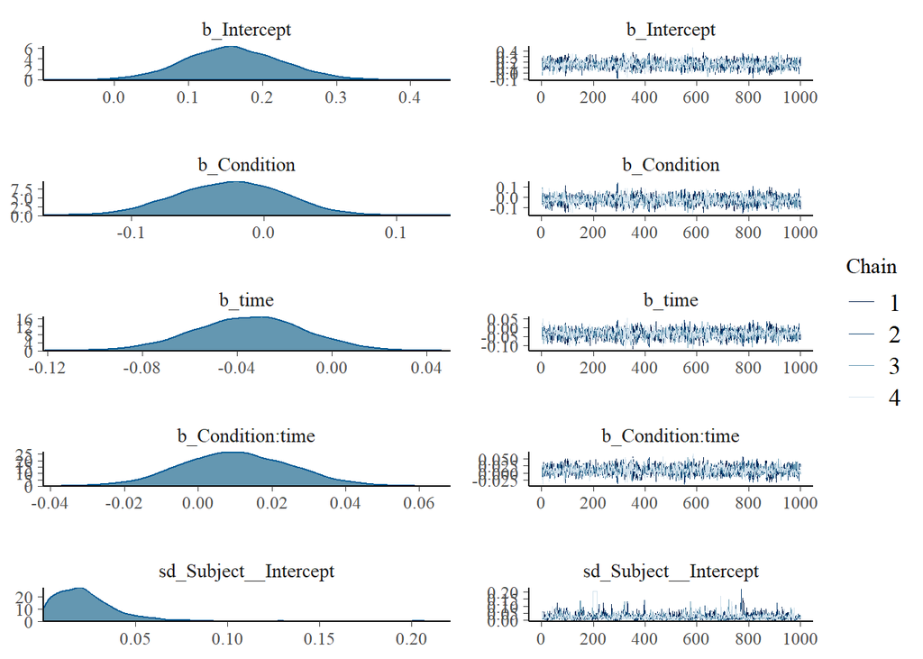

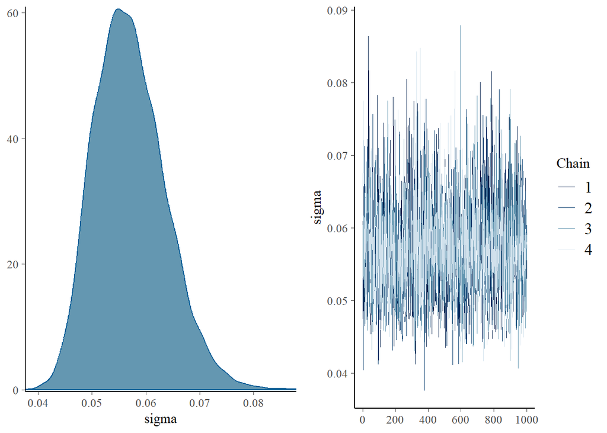

```r
plot(bmodel)
```

#### Reporting Communication with Behavioral Therapist

In our Bayesian analysis of ‘Communication with Behavioral Therapist’, the effect sizes for Condition (-0.02, 95% CI: -0.10, 0.05), time (-0.03, 95% CI: -0.08, 0.01), and the interaction effect Condition:time (0.01, 95% CI: -0.02, 0.04) are all relatively small, with 95% CIs spanning zero. The estimated standard deviation of the residuals (sigma) is 0.06 (95% CI: 0.05, 0.07), capturing variability not accounted for by the fixed effects. Our Bayesian analysis demonstrates convergence despite potential challenges, providing valuable insights into the intricate dynamics of children’s communication with a behavioral therapist over the course of the longitudinal study.